# Descriptive facts for work culture GitHub project

Jacob Toner Gosselin

29 April 2021

# Intro

This doc has the code and results for each variable outlined [here](https://docs.google.com/spreadsheets/d/1c49ib2oDodITWm66JfoQ4nshZbZ-YrHiZI8S4D1esHE/edit#gid=0).

Each section is dedicated to a specific variable. For each section, I have run the printed query in Google BigQuery and stored the resulting dataset on GCP under mcd-lab/work_culture. For descriptive statistics and graphs, I pull 10000 observations from each dataset (limiting to prevent RStudio from crashing, most of these datasets are >1 million rows). Details regarding my connection to Google BigQuery can be seen below.

```
## <BigQueryConnection>
##   Dataset: ghtorrent-bq.ght
##   Billing: mcd-lab
```

# Variable 1: Number of distinct projects working on

Our first variable is the “number of distinct projects working on”, observed at the person-week level, to measure being on multiple projects simultaneously. The query itself can be seen below; the resulting dataset is on GCP “mcd-lab/work_culture/var1_data”.

```
## <SQL> SELECT author_id, CONCAT(EXTRACT(WEEK FROM date(created_at)), EXTRACT(WEEK FROM date(created_at))) as week_year, COUNT(DISTINCT project_id) as num_projects FROM `ghtorrent-bq.ght.commits`
## group by author_id, CONCAT(EXTRACT(WEEK FROM date(created_at)), EXTRACT(WEEK FROM date(created_at)))
```

I pull means of variable one by week-year (resulting in 3510 observations), and graph/summarize the results below.

```
## var1_data$week_year_mean
##        n  missing distinct     Info     Mean      Gmd      .05      .10
##     3510        0     1376     0.83    1.163   0.2224    1.000    1.000
##      .25      .50      .75      .90      .95
##    1.000    1.000    1.337    1.500    1.602
##
## lowest : 1.000000 1.018519 1.025000 1.025641 1.026316
## highest: 2.285714 2.321604 3.000000 3.298488 3.416667
```

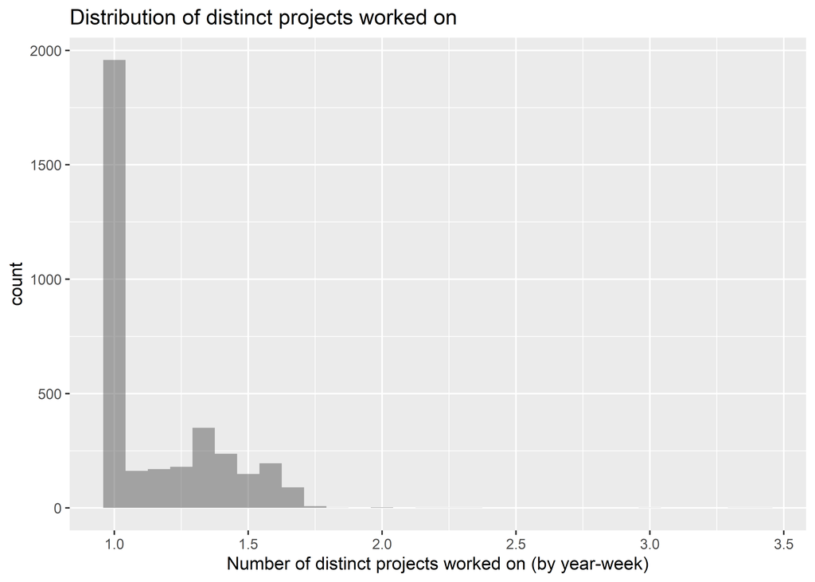

# Variable 2: percent of team members for which this is only team we share

Our second variable is the percent of project members for which this is the only project they share (unit of observation is person-project-week). This is a measure of how disconnected the projects are. I first query person-project-week combinations, with counts of the number of distinct projects they worked on that week. The query can be seen below; the data is stored on GCP under “mcd-lab/work_culture/var2_data”.

```
## <SQL> SELECT DISTINCT author_id, project_id, CONCAT(EXTRACT(WEEK FROM date(created_at)), EXTRACT(YEAR FROM date(created_at))) as week_year
## FROM `ghtorrent-bq.ght.commits`
## GROUP BY author_id, project_id, CONCAT(EXTRACT(WEEK FROM date(created_at)), EXTRACT(YEAR FROM date(created_at)))
```

I wrote a function to create dummy variables for whether the observation (person-project-week) represents the only project shared by co-editors; I could mapply this and get the desired dataset. **Flagging because I need some help here; I believe I’ve written a function that satisfies what we want, but it would take forever to run (I run it over only ten observations now and it takes a second; given that it increases linearly, it’s unfeasible to run this over the 1.1 million observations we have from January 2015)**.

```r
#pulling down the data (commented out since once I store it as a CSV I pull from that to avoid recharging Google BigQuery)
#var2_data = dbGetQuery(bq_con, var2_query_abridged)
#var2_data_sub = subset(var2_data, num_projects > 1)

get_mult_team = function(x, y, z){
  author_list1 = subset(var2_data_sub, week == y & project_id == z)
  author_list1 = subset(author_list1, author_list1 != x)
  proj_list = subset(var2_data_sub, author_id == x & week == y)$project_id
  proj_list = subset(proj_list, proj_list != z)
  author_list2 = subset(var2_data_sub, project_id %in% proj_list & week == y)$author_id
  author_list2 = subset(author_list2, author_list2 != x)
  return(ifelse(sum(author_list1 %in% author_list2) > 0, 1, 0))
}
```

# Variable 3: Number of new teams joined

Our third variable is number of new teams joined (unit of observation is person-year). This is a measure of being on multiple teams serially. The query itself can be seen below.

```
## <SQL> SELECT follower_id, EXTRACT(YEAR FROM date(created_at)) as year, COUNT(DISTINCT user_id) as num_projects
## FROM `ghtorrent-bq.ght.followers`
## group by follower_id, EXTRACT(YEAR FROM date(created_at))
```

I pull and a full year of data (2015; manageable size so I don’t need to subset). Distribution statistics and histograms for “num_projects” (i.e. the number of new projects a user worked on in a given year; unit of observation is person-year) can be seen below.

```
## var3_data$num_projects
##        n  missing distinct     Info     Mean      Gmd      .05      .10
##   590048        0      362     0.71    2.433    2.507        1        1
##      .25      .50      .75      .90      .95
##        1        1        2        4        6
##
## lowest :    1    2    3    4    5, highest: 2111 2459 2961 3789 4108
```

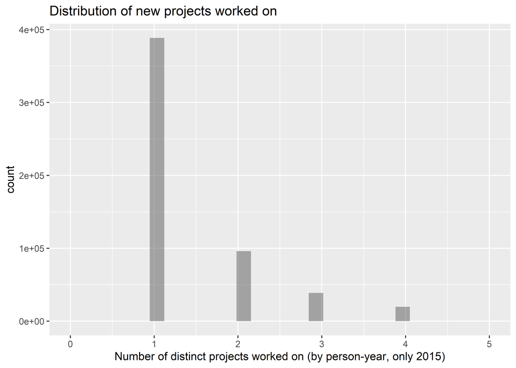

# Variable 4: Number of distinct authors working on project in given hour

Our fourth variable is number of distinct authors working on project in given hour (unit of observation is project-hour). This is a measure of how much work is synchronous. The query itself can be seen below.

```
## <SQL> SELECT project_id, EXTRACT(WEEK from created_at) as week, EXTRACT(DAY from created_at) as day, EXTRACT(HOUR from created_at) as hour, CONCAT(EXTRACT(WEEK from created_at), EXTRACT(YEAR from created_at)) as week_year, COUNT(DISTINCT author_id) as num_authors
## FROM `ghtorrent-bq.ght.commits`
## group by project_id, CONCAT(EXTRACT(WEEK from created_at), EXTRACT(YEAR from created_at)), EXTRACT(WEEK from created_at), EXTRACT(DAY FROM created_at), EXTRACT(HOUR FROM created_at)
```

I pull the mean number of authors working on a project and the percent of project-hours with more than one distinct author, by week. Distribution statistics and histograms for each can be seen below.

```
## var4_data$avg_authors
##        n  missing distinct     Info     Mean      Gmd      .05      .10
##     3510        0     1743    0.888    1.059  0.07809    1.000    1.000
##      .25      .50      .75      .90      .95
##    1.000    1.017    1.109    1.156    1.181
##
## lowest : 1.000000 1.005952 1.006667 1.007937 1.007937
## highest: 2.000000 2.125000 2.777778 3.250000 7.000000
##
## Value       1.00  1.05  1.10  1.15  1.20  1.25  1.30  1.35  1.40  1.50  2.00
## Frequency   1823   566   351   566   137    46     8     4     2     2     1
## Proportion 0.519 0.161 0.100 0.161 0.039 0.013 0.002 0.001 0.001 0.001 0.000
##
## Value       2.10  2.80  3.25  7.00
## Frequency      1     1     1     1
## Proportion 0.000 0.000 0.000 0.000
##
## For the frequency table, variable is rounded to the nearest 0.05
```

```
## var4_data$perc_more_one
##        n  missing distinct     Info     Mean      Gmd      .05      .10
##     3510        0     1731    0.995    7.562    4.636    1.085    2.835
##      .25      .50      .75      .90      .95
##    4.972    7.000    9.012   12.337   16.592
##
## lowest :  1.000000  1.004329  1.037037  1.142857  1.222222
## highest: 34.500000 36.000000 37.000000 42.000000 44.500000
```

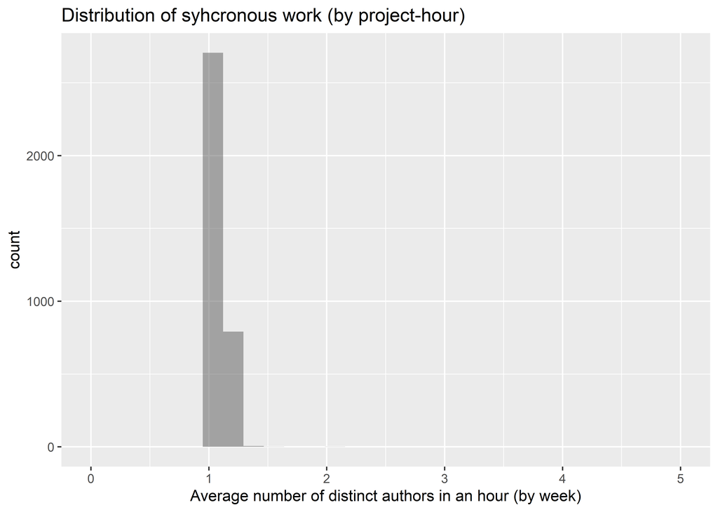

# Variable 5: Share of team members who joined partway through

Our fifth variable is number of distinct authors working on project who joined after the project was originally created. This is a measure of variation in team composition within its lifetime. I think defining this variable is a little difficult; if you define “late additions” as anyone added after the moment a project is created, that’s almost everyone. If you define it as anyone added on a different date than the project was created (i.e. a one day difference, minimum) that’s substantially less people. I define late additions using unique dates, weeks and months (i.e. “late_additions_day”, “late_additions_week”, “late_additions_month”). To do this I need to run 3 queries to generate the eventual dataset, and use leftjoins at each step. The final dataset is stored on GCP under “mcd-lab/work_culture/var5_data”.

```
## <SQL> SELECT repo_id, COUNT(DISTINCT user_id) as project_members, MIN(created_at) as project_created_at,
## FROM `ghtorrent-bq.ght.project_members`
## WHERE EXTRACT(YEAR FROM date(created_at)) = 2015
## GROUP BY repo_id
```

```
## <SQL>     SELECT `ghtorrent-bq.ght.project_members`.user_id, `mcd-lab.work_culture.var5_1`.repo_id, `mcd-lab.work_culture.var5_1`.project_members,       `mcd-lab.work_culture.var5_1`.project_creation,
## `ghtorrent-bq.ght.project_members`.created_at, TIMESTAMP_DIFF(`ghtorrent-bq.ght.project_members`.created_at, `mcd-lab.work_culture.var5_1`.project_creation, day) as days_late
##     FROM `mcd-lab.work_culture.var5_1` LEFT JOIN `ghtorrent-bq.ght.project_members` on `mcd-lab.work_culture.var5_1`.repo_id = `ghtorrent-bq.ght.project_members`.repo_id
```

```
## <SQL> SELECT repo_id, concat(EXTRACT(WEEK FROM MIN(date(created_at))), EXTRACT(YEAR FROM MIN(date(created_at)))) as week_year, AVG(project_members) as project_members, COUNTIF(days_late >= 1) as num_day_late, COUNTIF(days_late >= 7) as num_week_late,
## COUNTIF(days_late >= 30) as num_month_late, COUNTIF(days_late >= 1)/AVG(project_members) as perc_day_late, COUNTIF(days_late >= 7)/AVG(project_members) as perc_week_late,
## COUNTIF(days_late >= 30)/AVG(project_members) as perc_month_late
## FROM `mcd-lab.work_culture.var5_2`
## GROUP BY repo_id
```

I pull and store each variable (late additions by day, week, and month) averaged over week-year combination. I describe each below.

```
## var5_data$avg_perc_day
##        n  missing distinct     Info     Mean      Gmd      .05      .10
##      461        0      460        1   0.0477  0.03367  0.01198  0.01641
##      .25      .50      .75      .90      .95
##  0.02916  0.04025  0.05352  0.06245  0.07494
##
## lowest : 0.0000000000 0.0002508529 0.0041177152 0.0043605653 0.0052314430
## highest: 0.2902116402 0.3750000000 0.5750000000 0.7777777778 0.8888888889
##
## Value       0.00  0.01  0.02  0.03  0.04  0.05  0.06  0.07  0.08  0.09  0.10
## Frequency      5    31    44   105    91    83    68    11     5     2     2
## Proportion 0.011 0.067 0.095 0.228 0.197 0.180 0.148 0.024 0.011 0.004 0.004
##
## Value       0.11  0.12  0.18  0.22  0.29  0.37  0.57  0.78  0.89
## Frequency      2     4     1     2     1     1     1     1     1
## Proportion 0.004 0.009 0.002 0.004 0.002 0.002 0.002 0.002 0.002
##
## For the frequency table, variable is rounded to the nearest 0.01
```

```
## var5_data$avg_perc_week
##        n  missing distinct     Info     Mean      Gmd      .05      .10
##      461        0      459        1  0.03942  0.03017 0.007538 0.010618
##      .25      .50      .75      .90      .95
## 0.024710 0.031931 0.039326 0.047852 0.071633
##
## lowest : 0.0000000000 0.0001258988 0.0038881917 0.0041536865 0.0042073614
## highest: 0.2902116402 0.3750000000 0.5541666667 0.7777777778 0.8888888889
##
## Value       0.00  0.01  0.02  0.03  0.04  0.05  0.06  0.07  0.08  0.09  0.10
## Frequency      9    51    60   168   111    29     7     6     4     1     1
## Proportion 0.020 0.111 0.130 0.364 0.241 0.063 0.015 0.013 0.009 0.002 0.002
##
## Value       0.11  0.12  0.18  0.22  0.29  0.37  0.55  0.78  0.89
## Frequency      3     3     2     1     1     1     1     1     1
## Proportion 0.007 0.007 0.004 0.002 0.002 0.002 0.002 0.002 0.002
##
## For the frequency table, variable is rounded to the nearest 0.01
```

```
## var5_data$avg_perc_month
##        n  missing distinct     Info     Mean      Gmd      .05      .10
##      461        0      455        1  0.03178  0.02854 0.004551 0.006423
##      .25      .50      .75      .90      .95
## 0.016853 0.024327 0.031925 0.043679 0.066871
##
## lowest : 0.0000000000 0.0008651542 0.0018840452 0.0022520970 0.0029623728
## highest: 0.2902116402 0.3750000000 0.3791666667 0.7777777778 0.8518518519
##
## Value       0.00  0.01  0.02  0.03  0.04  0.05  0.06  0.07  0.08  0.09  0.10
## Frequency     28    73   138   135    45    13     5     5     4     2     3
## Proportion 0.061 0.158 0.299 0.293 0.098 0.028 0.011 0.011 0.009 0.004 0.007
##
## Value       0.11  0.14  0.17  0.29  0.37  0.38  0.78  0.85
## Frequency      3     1     1     1     1     1     1     1
## Proportion 0.007 0.002 0.002 0.002 0.002 0.002 0.002 0.002
##
## For the frequency table, variable is rounded to the nearest 0.01
```